# Algorithms for Big Data - Exercise 4

This lecture is focused in more detailed understanding of the Convolution neural networks.

We will use the MNIST dataset but other may be used as well.

[Open in Google colab](https://colab.research.google.com/github/rasvob/2020-21-ARD/blob/master/abd_04.ipynb) [Download from Github](https://github.com/rasvob/2020-21-ARD/blob/master/abd_04.ipynb)

```python
from __future__ import absolute_import
from __future__ import division
from __future__ import print_function

import matplotlib.pyplot as plt # plotting
import matplotlib.image as mpimg # images
import numpy as np #numpy
import tensorflow.compat.v2 as tf #use tensorflow v2 as a main
import tensorflow.keras as keras # required for high level applications
from sklearn.model_selection import train_test_split # split for validation sets
from sklearn.preprocessing import normalize # normalization of the matrix
from scipy.signal import convolve2d # convolutionof the 2D signals
import scipy
import datetime, os

tf.version.VERSION
```

```
'2.8.0'
```

```python
%load_ext tensorboard
```

```python
def show_history(history):
    plt.figure()
    for key in history.history.keys():
        plt.plot(history.epoch, history.history[key], label=key)
    plt.legend()
    plt.tight_layout()

def show_example(train_x, train_y, class_names):
    plt.figure(figsize=(10,10))
    for i in range(25):
        plt.subplot(5,5,i+1)
        plt.xticks([])
        plt.yticks([])
        plt.grid(False)
        plt.imshow(train_x[i].reshape(28,28), cmap=plt.cm.binary)
        plt.xlabel(class_names[train_y[i]])
    plt.show()
```

```python
class Mish(keras.layers.Activation):
    '''
    Mish Activation Function.
    .. math::
        mish(x) = x * tanh(softplus(x)) = x * tanh(ln(1 + e^{x}))
    Shape:
        - Input: Arbitrary. Use the keyword argument `input_shape`
        (tuple of integers, does not include the samples axis)
        when using this layer as the first layer in a model.
        - Output: Same shape as the input.
    Examples:
        >>> X = Activation('Mish', name="conv1_act")(X_input)
    '''

    def __init__(self, activation, **kwargs):
        super(Mish, self).__init__(activation, **kwargs)
        self.__name__ = 'Mish'


def mish(inputs):
    return inputs * tf.math.tanh(tf.math.softplus(inputs))

keras.utils.get_custom_objects().update({'mish': Mish(mish)})
```

```python
# mnist is the basic dataset for image classifaction
dataset = tf.keras.datasets.mnist

# data from any dataset are loaded using the load_Data function
(train_x, train_y), (test_x, test_y) = dataset.load_data()

train_x = train_x.reshape(*train_x.shape, 1)
test_x = test_x.reshape(*test_x.shape, 1)

train_x = train_x/255.0
test_x = test_x/255.0

train_x, valid_x, train_y, valid_y = train_test_split(train_x, train_y, test_size=0.2, random_state=42)

# the data are in the form of 32x32 pixes with values 0-255.
print('Train data shape: ', train_x.shape, train_y.shape)
print('Validation data shape: ', valid_x.shape, valid_y.shape)
print('Test data shape:  ', test_x.shape, test_y.shape)

# class_names = ['airplane', 'automobile', 'bird', 'cat', 'deer', 'dog', 'frog', 'horse', 'ship', 'truck']
class_names = [str(x) for x in range(10)]
# class_names = ['T-shirt/top', 'Trouser', 'Pullover', 'Dress', 'Coat', 'Sandal', 'Shirt', 'Sneaker', 'Bag', 'Ankle boot']
class_count = len(class_names)
print('Class count:', class_count, class_names)
```

```
Downloading data from https://storage.googleapis.com/tensorflow/tf-keras-datasets/mnist.npz
Train data shape:  (48000, 28, 28, 1) (48000,)
Validation data shape:  (12000, 28, 28, 1) (12000,)
Test data shape:   (10000, 28, 28, 1) (10000,)
Class count: 10 ['0', '1', '2', '3', '4', '5', '6', '7', '8', '9']
```

#### Show example images of the dataset

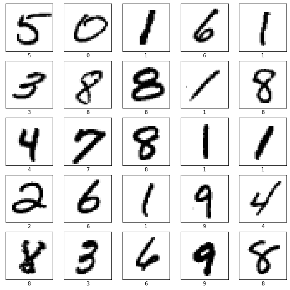

```python
show_example(train_x, train_y, class_names)
```

### Create a well defined model

```python
model = keras.Sequential([
    keras.layers.Conv2D(64, (3,3), activation='relu', padding='same', input_shape=(28,28,1)),
    keras.layers.MaxPooling2D((2, 2), padding='same'),
    keras.layers.Conv2D(64, (3,3), padding='same', activation='relu'),
    keras.layers.MaxPooling2D((2, 2), padding='same'),
    keras.layers.Conv2D(16, (3,3), padding='same', activation='relu'),
    keras.layers.MaxPooling2D((2, 2), padding='same'),

    keras.layers.Flatten(),
    keras.layers.Dense(64, activation='relu'),
    keras.layers.Dropout(0.25),
    keras.layers.Dense(32, activation='relu'),
    keras.layers.Dropout(0.25),
    keras.layers.Dense(10, activation='softmax'),
])

model.summary()

model.compile(loss='sparse_categorical_crossentropy',
              optimizer='adam',
              metrics=['accuracy'])
```

```
Model: "sequential"
_________________________________________________________________
 Layer (type)                Output Shape              Param #
=================================================================
 conv2d (Conv2D)             (None, 28, 28, 64)        640

 max_pooling2d (MaxPooling2D  (None, 14, 14, 64)       0
 )

 conv2d_1 (Conv2D)           (None, 14, 14, 64)        36928

 max_pooling2d_1 (MaxPooling  (None, 7, 7, 64)         0
 2D)

 conv2d_2 (Conv2D)           (None, 7, 7, 16)          9232

 max_pooling2d_2 (MaxPooling  (None, 4, 4, 16)         0
 2D)

 flatten (Flatten)           (None, 256)               0

 dense (Dense)               (None, 64)                16448

 dropout (Dropout)           (None, 64)                0

 dense_1 (Dense)             (None, 32)                2080

 dropout_1 (Dropout)         (None, 32)                0

 dense_2 (Dense)             (None, 10)                330

=================================================================
Total params: 65,658
Trainable params: 65,658
Non-trainable params: 0
_________________________________________________________________
```

#### Fit the model on the train data.

Lets train the model on the training data and find the best model using the EarlyStopping callback to find the best model avaialble and achievable.

```
Test accuracy:  0.9879999756813049
```

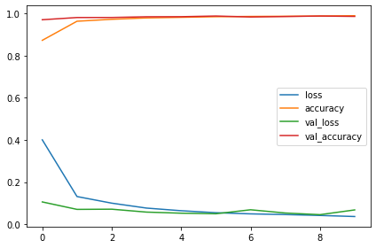

```python
es = keras.callbacks.EarlyStopping(monitor='val_loss', min_delta=0, patience=7, restore_best_weights=True)
logdir = os.path.join("logs", datetime.datetime.now().strftime("%Y%m%d-%H%M%S"))
tensorboard_callback = tf.keras.callbacks.TensorBoard(logdir, histogram_freq=1)

# batch_size = 32
# epochs = 50

batch_size = 32
epochs = 10
history = model.fit(train_x, train_y, validation_data=(valid_x, valid_y), callbacks=[es, tensorboard_callback], epochs=epochs, batch_size=batch_size)

show_history(history)

test_loss, test_acc = model.evaluate(test_x, test_y)
print('Test accuracy: ', test_acc)
```

## Let's try the tensorboard plugin

```python
%tensorboard --logdir logs
```

## Visualize the layers

Lest see what the network was able to learn from the train data. For that, we need to prepare a new model and see the ouputs of the layers.

```python
# get the outputs form all layers in the model
layer_outputs = [layer.output for layer in model.layers]
# create the model that has single input and as an output all the outputs from the layers.
# Because the layers are connected then the output from first layer is propagated into second layer and the output is computed o it.
activation_model = keras.models.Model(inputs=model.input, outputs=layer_outputs)

# get all the outputs from the model for 10-th input
activations = activation_model.predict(train_x[10].reshape(1,28,28,1))

# this functions shows the output from each filters
def display_activation(activations, col_size, row_size, act_index):
    activation = activations[act_index]
    activation_index=0
    fig, ax = plt.subplots(row_size, col_size, figsize=(row_size*2.5,col_size*1.5))
    for row in range(0,row_size):
        for col in range(0,col_size):
            ax[row][col].imshow(activation[0, :, :, activation_index], cmap='gray')
            activation_index += 1
```

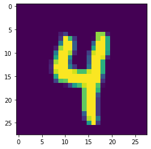

```python
# show the input image
plt.imshow(train_x[10][:,:,0]);
```

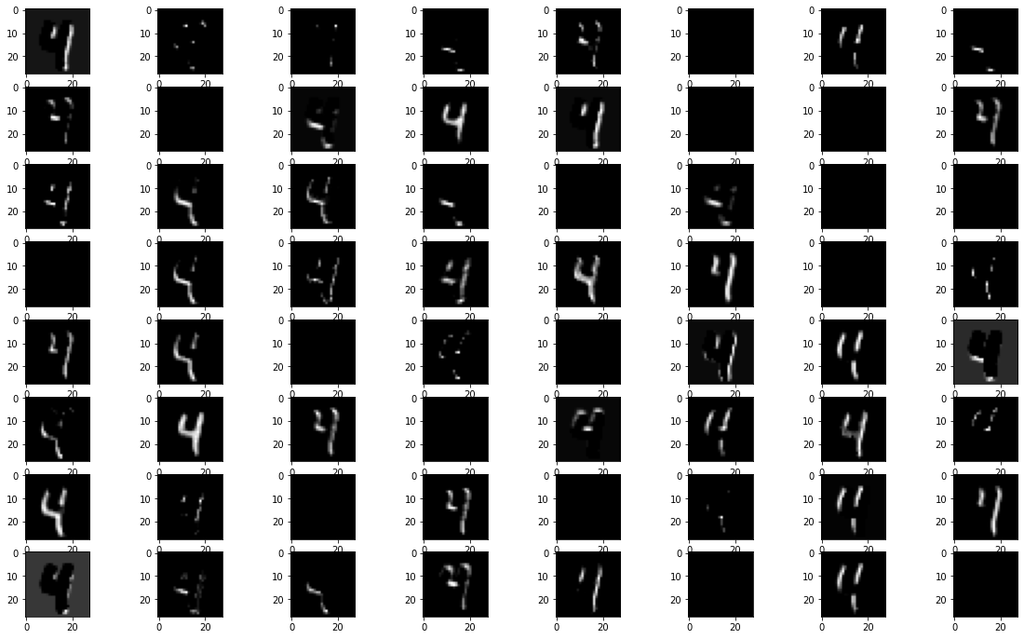

```python
# show the output from the first layer - CNN2D
display_activation(activations, 8, 8, 0)
```

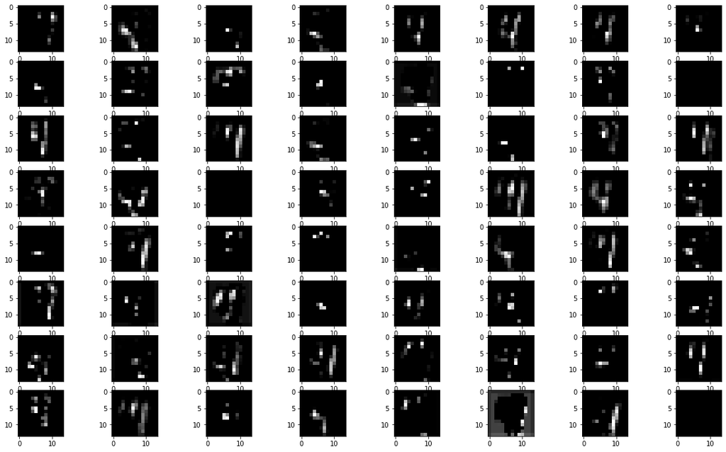

```python
# show the second convolution layer
display_activation(activations, 8, 8, 2)
```

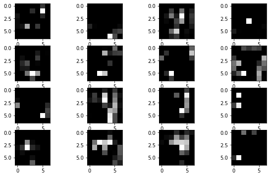

```python
# show the third activation layer
display_activation(activations, 4, 4, 4)
```

## The weights of each layer

The weight can be extracted from layer as a tuple of weights and biasses

```python
filters, biases = model.layers[0].get_weights()
print(filters.shape, biases.shape)
```

```
(3, 3, 1, 64) (64,)
```

```python
#### The weights may be normalized in to 0-1 interval
```

```python
f_min, f_max = filters.min(), filters.max()
filters = (filters - f_min) / (f_max - f_min)
```

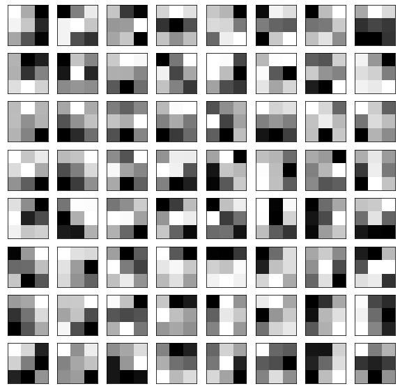

```python
plt.figure(figsize=(10,10))

# plot first few filters
n_filters = 64
for i in range(n_filters):
    # get the filter
    f = filters[:, :, :, i]
    # plot each channel separately
    # specify subplot and turn of axis
    ax = plt.subplot(8, 8, i+1)
    ax.set_xticks([])
    ax.set_yticks([])
    # plot filter channel in grayscale
    plt.imshow(f[:, :, 0], cmap='gray')

# show the figure
plt.show()
```

## Autoencoder

The autoencoder is a special type of neural network that is able to learn without the classes just from the input data. It is equivalent to the feature extraction from the data.

It's worth a mention that we are using binary crossentropy loss, thus we compare images on per-pixel basis.

- You can view [this link](https://towardsdatascience.com/understanding-binary-cross-entropy-log-loss-a-visual-explanation-a3ac6025181a) for more information about Bin. CE

```python
autoencoder = keras.Sequential([
    keras.layers.Conv2D(64, (3,3), activation='relu', padding='same', input_shape=(28,28,1)),
    keras.layers.MaxPooling2D((2, 2), padding='same'),
    keras.layers.Conv2D(32, (3,3), padding='same', activation='relu'),
    keras.layers.MaxPooling2D((2, 2), padding='same'),
    keras.layers.Conv2D(8, (3,3), padding='same', activation='relu'),
    keras.layers.MaxPooling2D((2, 2), padding='same'),
    # a 128 values of the minimized knowledge / features
    keras.layers.Conv2D(8, (3,3), padding='same', activation='relu'),
    keras.layers.UpSampling2D((2,2)),
    keras.layers.Conv2D(32, (3,3), padding='same', activation='relu'),
    keras.layers.UpSampling2D((2,2)),
    keras.layers.Conv2D(64, (3,3), activation='relu'),
    keras.layers.UpSampling2D((2,2)),

    keras.layers.Conv2D(1, (3,3), activation='sigmoid', padding='same')
])

autoencoder.summary()

autoencoder.compile(loss='binary_crossentropy', optimizer='adam', metrics=['accuracy'])
```

```
Model: "sequential_1"
_________________________________________________________________
 Layer (type)                Output Shape              Param #
=================================================================
 conv2d_3 (Conv2D)           (None, 28, 28, 64)        640

 max_pooling2d_3 (MaxPooling  (None, 14, 14, 64)       0
 2D)

 conv2d_4 (Conv2D)           (None, 14, 14, 32)        18464

 max_pooling2d_4 (MaxPooling  (None, 7, 7, 32)         0
 2D)

 conv2d_5 (Conv2D)           (None, 7, 7, 8)           2312

 max_pooling2d_5 (MaxPooling  (None, 4, 4, 8)          0
 2D)

 conv2d_6 (Conv2D)           (None, 4, 4, 8)           584

 up_sampling2d (UpSampling2D  (None, 8, 8, 8)          0
 )

 conv2d_7 (Conv2D)           (None, 8, 8, 32)          2336

 up_sampling2d_1 (UpSampling  (None, 16, 16, 32)       0
 2D)

 conv2d_8 (Conv2D)           (None, 14, 14, 64)        18496

 up_sampling2d_2 (UpSampling  (None, 28, 28, 64)       0
 2D)

 conv2d_9 (Conv2D)           (None, 28, 28, 1)         577

=================================================================
Total params: 43,409
Trainable params: 43,409
Non-trainable params: 0
_________________________________________________________________
```

### Fit the model

The model may be fitted as much as possible, this model converges but slowly.

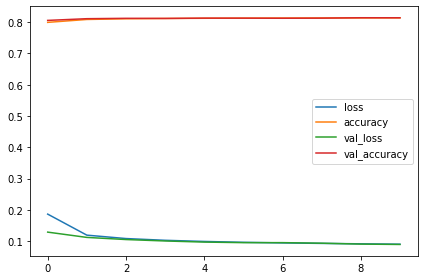

```python
history = autoencoder.fit(train_x, train_x, validation_data=(valid_x, valid_x), epochs=10, batch_size=128)

show_history(history)
```

### Generate original and reconstructed images

The autoencoder fits on the original data on input as well as on output, therefore it is possible to generate reconstructed images.

Zvětšení prostřední vrstvy s účelem zajištění větší přesnosti rekonstrukce.

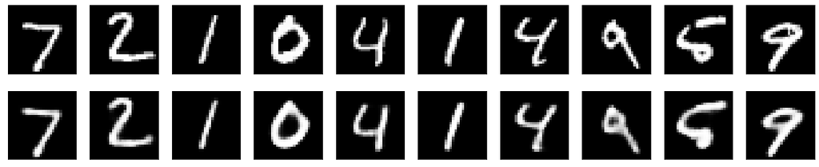

```python
predicted = autoencoder.predict(test_x)

n = 10
plt.figure(figsize=(20, 4))
for i in range(n):
    # display original
    ax = plt.subplot(2, n, i+1)
    plt.imshow(test_x[i].reshape(28, 28))
    plt.gray()
    ax.get_xaxis().set_visible(False)
    ax.get_yaxis().set_visible(False)

    # display reconstruction
    ax = plt.subplot(2, n, i + 1+n)
    plt.imshow(predicted[i].reshape(28, 28))
    plt.gray()
    ax.get_xaxis().set_visible(False)
    ax.get_yaxis().set_visible(False)
plt.show()
```

### Vizualize the encoded vectors

The vectors that are generated by the encoder may be vizualized.

```python
encoder = keras.Sequential([
    keras.layers.Conv2D(64, (3,3), activation='relu', padding='same', input_shape=(28,28,1)),
    keras.layers.MaxPooling2D((2, 2), padding='same'),
    keras.layers.Conv2D(32, (3,3), padding='same', activation='relu'),
    keras.layers.MaxPooling2D((2, 2), padding='same'),
    keras.layers.Conv2D(8, (3,3), padding='same', activation='relu'),
    keras.layers.MaxPooling2D((2, 2), padding='same'),
])

# encoder.compile(optimizer='adam', loss='binary_crossentropy')
encoder.set_weights(autoencoder.get_weights()[:6])

for layer in encoder.layers:
  layer.trainable = False

encoder.summary()
```

```
Model: "sequential_2"
_________________________________________________________________
 Layer (type)                Output Shape              Param #
=================================================================
 conv2d_10 (Conv2D)          (None, 28, 28, 64)        640

 max_pooling2d_6 (MaxPooling  (None, 14, 14, 64)       0
 2D)

 conv2d_11 (Conv2D)          (None, 14, 14, 32)        18464

 max_pooling2d_7 (MaxPooling  (None, 7, 7, 32)         0
 2D)

 conv2d_12 (Conv2D)          (None, 7, 7, 8)           2312

 max_pooling2d_8 (MaxPooling  (None, 4, 4, 8)          0
 2D)

=================================================================
Total params: 21,416
Trainable params: 0
Non-trainable params: 21,416
_________________________________________________________________
```

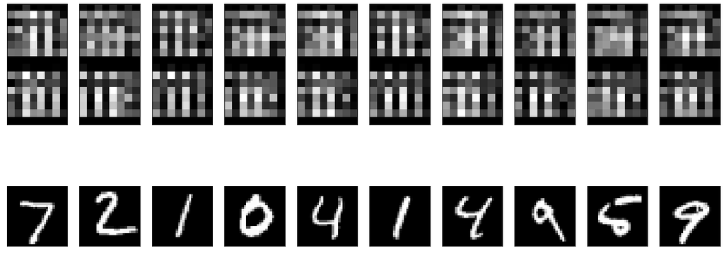

```python
encoded = encoder.predict(test_x)

n = 10
plt.figure(figsize=(20, 8))
for i in range(n):
    ax = plt.subplot(2, n, i+1)
    plt.imshow(encoded[i].reshape(8, 16).T)
    plt.gray()
    ax.get_xaxis().set_visible(False)
    ax.get_yaxis().set_visible(False)

    ax = plt.subplot(2, n, n+i+1)
    plt.imshow(test_x[i].reshape(28,28))
    plt.gray()
    ax.get_xaxis().set_visible(False)
    ax.get_yaxis().set_visible(False)
plt.show()
```

### Is the encoder-based classifier better than the previous one above?

The encoder generated using the autoencoder principle generate a compressed representation of the input. The inner vector with 128 values is much smaller and the goal of the autoencoder is different than from the classifier, therefore the generated representation is usually better using the classifier directly. Some variants of encoder are able to generate better representation - a sparse autoencoders that generate sparse representation for example.

### Is it possible to control how sparse our representation will be? If it's possible, what method would you use? [API](https://keras.io/api/layers/regularizers/)

### Why is it usually better to use classifier directly and not train encoder for feature extraction first and then put classification layers on top of it?

```python
encoder.add(keras.layers.Flatten())
encoder.add(keras.layers.Dense(64, activation='relu'))
encoder.add(keras.layers.Dropout(0.25))
encoder.add(keras.layers.Dense(32, activation='relu'))
encoder.add(keras.layers.Dropout(0.25))
encoder.add(keras.layers.Dense(10, activation='softmax'))
```

```python
encoder.compile(optimizer='adam', loss='sparse_categorical_crossentropy', metrics = ['accuracy'])
encoder.summary()
```

```
Model: "sequential_2"
_________________________________________________________________
 Layer (type)                Output Shape              Param #
=================================================================
 conv2d_10 (Conv2D)          (None, 28, 28, 64)        640

 max_pooling2d_6 (MaxPooling  (None, 14, 14, 64)       0
 2D)

 conv2d_11 (Conv2D)          (None, 14, 14, 32)        18464

 max_pooling2d_7 (MaxPooling  (None, 7, 7, 32)         0
 2D)

 conv2d_12 (Conv2D)          (None, 7, 7, 8)           2312

 max_pooling2d_8 (MaxPooling  (None, 4, 4, 8)          0
 2D)

 flatten_1 (Flatten)         (None, 128)               0

 dense_3 (Dense)             (None, 64)                8256

 dropout_2 (Dropout)         (None, 64)                0

 dense_4 (Dense)             (None, 32)                2080

 dropout_3 (Dropout)         (None, 32)                0

 dense_5 (Dense)             (None, 10)                330

=================================================================
Total params: 32,082
Trainable params: 10,666
Non-trainable params: 21,416
_________________________________________________________________
```

```
Test accuracy:  0.9526000022888184
```

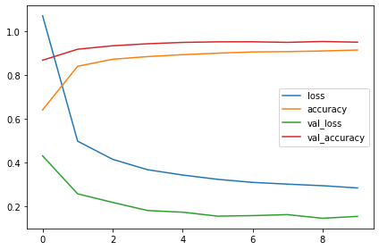

```python
es = keras.callbacks.EarlyStopping(monitor='val_loss', min_delta=0, patience=7, restore_best_weights=True)

history = encoder.fit(train_x, train_y, validation_data=(valid_x, valid_y), callbacks = [es], epochs=10)

show_history(history)

test_loss, test_acc = encoder.evaluate(test_x, test_y)
print('Test accuracy: ', test_acc)
```

## Outlier analysis

Let use the autoencoder as an outlier analyzer.

First, prepare the testing set. then create a outlier data and compare the prediction error on the both.

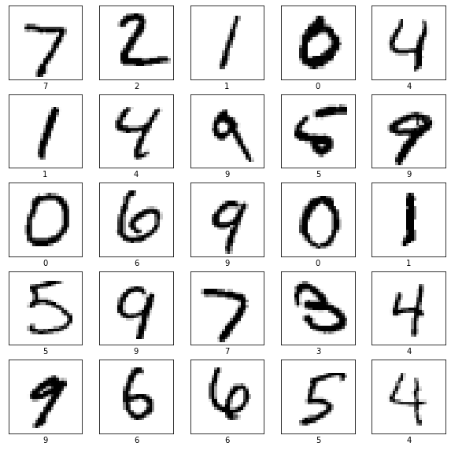

```python
sample_x = test_x[:25]
sample_y = test_y[:25]

show_example(sample_x, sample_y, class_names)
```

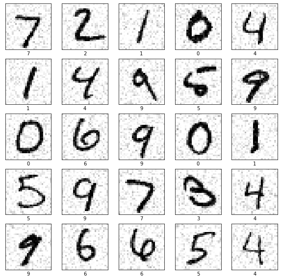

```python
modified_x = np.clip(sample_x + 0.1 * np.random.normal(loc=0.0, scale=1.0, size=sample_x.shape), 0., 1.)
modified_y = sample_y
show_example(modified_x, modified_y, class_names)
```

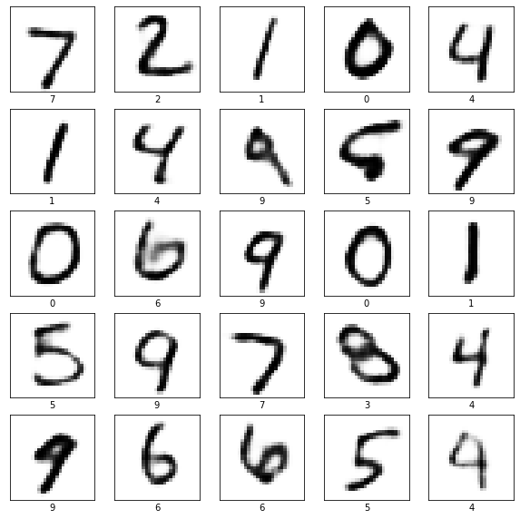

```python
sample_predicted = autoencoder.predict(sample_x)
show_example(sample_predicted, sample_y, class_names)
```

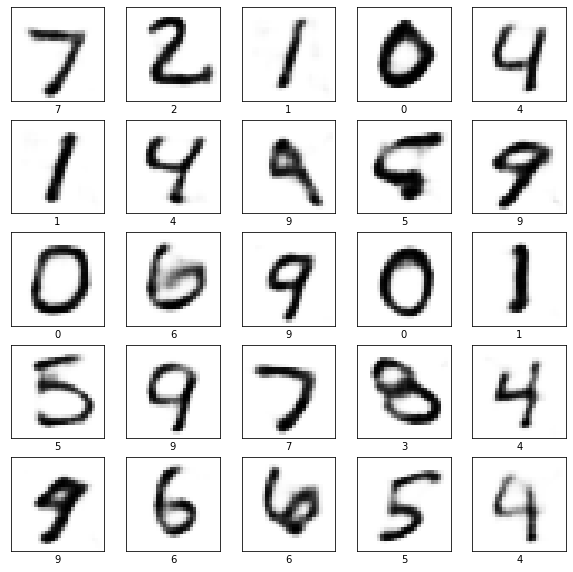

```python
modified_pred = autoencoder.predict(modified_x)
show_example(modified_pred, modified_y, class_names)
```

```python
# https://numpy.org/doc/stable/reference/generated/numpy.linalg.norm.html
# np.linalg.norm -> Frobenius norm ~ root of squared errors

sample_norms = [np.linalg.norm(sample_x[i].reshape(28,28)- sample_predicted[i].reshape(28,28)) for i in range(len(sample_x))]
modified_norms = [np.linalg.norm(modified_x[i].reshape(28,28)- modified_pred[i].reshape(28,28)) for i in range(len(sample_x))]

sample_mean, sample_std = np.mean(sample_norms), np.std(sample_norms)
modified_mean, modified_std = np.mean(modified_norms), np.std(modified_norms)
```

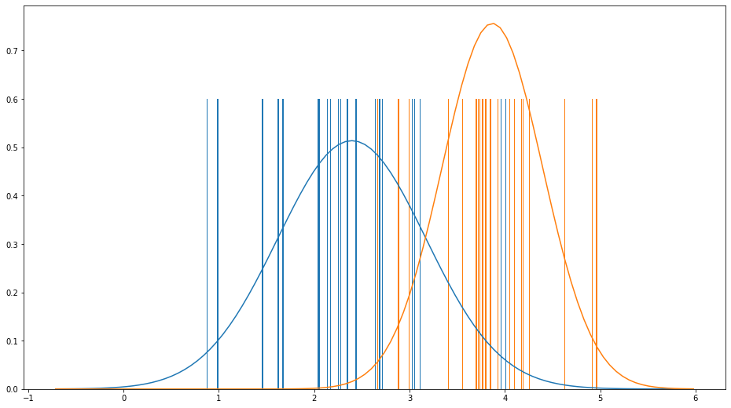

```python
plt.figure(figsize=(16,9))
xmin = np.min([sample_mean-4*sample_std, modified_mean-4*modified_std])
xmax = np.max([sample_mean+4*sample_std, modified_mean+4*modified_std])

x = np.linspace(xmin, xmax, 100)

y = scipy.stats.norm.pdf(x,sample_mean,sample_std)

plt.plot(x,y)

y = scipy.stats.norm.pdf(x,modified_mean,modified_std)

plt.plot(x,y)

plt.bar(x=sample_norms, height=[0.6 for x in sample_norms], width=0.01)
plt.bar(x=modified_norms, height=[0.6 for x in sample_norms], width=0.01)
plt.show()
```

## Denoising-autoencoder

The denoising autoencoder is a autoencoder that will learn how to remove random noise from the images.

First, noisy images have to be generated.

Then the autoencoder need to be created and trained.

Then denosed images may be reconstructed.

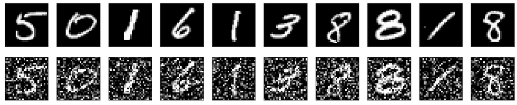

```python
noise_factor = 0.5
noisy_train_x = np.clip(train_x + noise_factor * np.random.normal(loc=0.0, scale=1.0, size=train_x.shape), 0., 1.)
noisy_valid_x = np.clip(valid_x + noise_factor * np.random.normal(loc=0.0, scale=1.0, size=valid_x.shape), 0., 1.)
noisy_test_x = np.clip(test_x + noise_factor * np.random.normal(loc=0.0, scale=1.0, size=test_x.shape), 0., 1.)


n = 10
plt.figure(figsize=(2*n, 4))
for i in range(n):
    ax = plt.subplot(2, n, i+1)
    plt.imshow(train_x[i].reshape(28,28))
    plt.gray()
    ax.get_xaxis().set_visible(False)
    ax.get_yaxis().set_visible(False)

    ax = plt.subplot(2, n, n+i+1)
    plt.imshow(noisy_train_x[i].reshape(28,28))
    plt.gray()
    ax.get_xaxis().set_visible(False)
    ax.get_yaxis().set_visible(False)
plt.show()
```

## Tasks for Lecture / Exercise

1. Implement the autoencoder that do something usefull like denoising, implement it on the data defined above.
2. The Keras contains stored models that may be used for classification. The pretrained models may be used effectivelly to classify data, e.g. images, using the state of the art models. Try to investigate the architecture of the stored models and use the for classification of sample data downloaded from the internet.
   1. Try VGG16 model and investigrate its architecture.
   2. Try ResNet model architecture.
- See [Keras Functional API](https://keras.io/guides/functional_api/)
- See [this for VGG16 and ResNet fine tuning](https://keras.io/api/applications/), chapter Fine-tune InceptionV3 on a new set of classes

```python
from tensorflow.keras.applications.vgg19 import VGG19
from tensorflow.keras.applications.resnet50 import ResNet50
import cv2
```

```python
def grayscale_to_rgb(images, channel_axis=-1):
    # images= keras.backend.expand_dims(images, axis=channel_axis)
    tiling = [1] * 4    # 4 dimensions: B, H, W, C
    tiling[channel_axis] *= 3
    images= keras.backend.tile(images, tiling)
    return images
```

```python
size = 32
```

```python
train_x_res = np.array([cv2.resize(x, (size, size)) for x in train_x])
test_x_res = np.array([cv2.resize(x, (size, size)) for x in test_x])
valid_x_res = np.array([cv2.resize(x, (size, size)) for x in valid_x])
```

```python
train_x_r = train_x_res.reshape(-1, size, size, 1).astype('float32')
test_x_r = test_x_res.reshape(-1, size, size, 1).astype('float32')
valid_x_r = valid_x_res.reshape(-1, size, size, 1).astype('float32')
```

```python
train_x_r = grayscale_to_rgb(train_x_r)
test_x_r = grayscale_to_rgb(test_x_r)
valid_x_r = grayscale_to_rgb(valid_x_r)
```

- vstup šum
- vystup normální obrázky